# Written Assignment 06

Author

Owen Senowitz

Published

November 16, 2024

# Assignment Goal

The overarching goal for this assignment is to assess your understanding of the probability-based machine learning algorithms.

# Instructions

Please show all your work. Simply providing the final answer is treated as no response. If you do not use R or Python notebooks, it is fine. However, the document structure should be preserved if you choose to use Microsoft Word or something else.

Please submit your response either as a self-contained HTML or PDF document.

# 1 Computing Probability - Equally Likely Outcomes

1. Three people flip a fair coin. What is the probability that exactly two of them will get heads?

   The probability that exactly two of them will get heads when three people flip a coin is 0.375
2. Twenty people flip a fair coin. What is the probability that exactly eight of them will get heads?

   The probability that exactly eight of them will get heads when twenty people flip a coin is 0.1201
3. Twenty people flip a fair coin. What is the probability that at least four of them will get heads?

   The probability that at least four people will get heads when twenty people flip a fair coin is 0.9987

# 2 Estimating Probabilities

The table gives details of symptoms that patients presented and whether they were suffering from meningitis.

| ID | Headache | Fever | Vomiting | Meningitis |
| --- | --- | --- | --- | --- |
| 1 | TRUE | TRUE | FALSE | FALSE |
| 2 | FALSE | TRUE | FALSE | FALSE |
| 3 | TRUE | FALSE | TRUE | FALSE |
| 4 | TRUE | FALSE | TRUE | FALSE |
| 5 | FALSE | TRUE | FALSE | TRUE |
| 6 | TRUE | FALSE | TRUE | FALSE |
| 7 | TRUE | FALSE | TRUE | FALSE |
| 8 | TRUE | FALSE | TRUE | TRUE |
| 9 | FALSE | TRUE | FALSE | FALSE |
| 10 | TRUE | FALSE | TRUE | TRUE |

Data for a predicting Meningitis.

Using this dataset calculate the following probabilities:

1. P(Vomiting = true)

   0.6
2. P(Headache = false)

   0.3
3. P(Headache = true, Vomiting = false)

   0.1
4. P(Vomiting = false $\mid$ Headache = true)

   0.1429
5. P(Meningitis $\mid$ Fever = true, Vomiting = false)

   0.25

# 3 Naive Bayes Model

Predictive data analytics models are often used as tools for process quality control and fault detection. The task in this question is to create a naive Bayes model to monitor a waste water treatment plant. The table below lists a dataset containing details of activities at a waste water treatment plant for 13 days. Each day is described in terms of six descriptive features that are generated from different sensors at the plant. SS-IN measures the solids coming into the plant per day; SED-IN measures the sediment coming into the plant per day; COND-IN measures the electrical conductivity of the water coming into the plant. The features SS-OUT, SED-OUT, and COND-OUT are the corresponding measurements for the water flowing out of the plant. The target feature, STATUS, reports the current situation at the plant: ok, everything is working correctly; settler, there is a problem with the plant settler equipment; or solids, there is a problem with the amount of solids going through the plant.

| ID | SS-IN | SED-IN | COND-IN | SS-OUT | SED-OUT | COND-OUT | STATUS |
| --- | --- | --- | --- | --- | --- | --- | --- |
| 1 | 168 | 3.0 | 1814 | 15.0 | 0.001 | 1879.0 | ok |
| 2 | 156 | 3.0 | 1358 | 14.0 | 0.010 | 1425.0 | ok |
| 3 | 176 | 3.5 | 2200 | 16.0 | 0.005 | 2140.0 | ok |
| 4 | 256 | 3.0 | 2070 | 27.0 | 0.200 | 2700.0 | ok |
| 5 | 230 | 5.0 | 1410 | 131.0 | 3.500 | 1575.0 | settler |
| 6 | 116 | 3.0 | 1238 | 104.0 | 0.060 | 1221.0 | settler |
| 7 | 242 | 7.0 | 1315 | 104.0 | 0.010 | 1434.0 | settler |
| 8 | 242 | 4.5 | 1183 | 78.0 | 0.020 | 1374.0 | settler |
| 9 | 174 | 2.5 | 1110 | 73.0 | 1.500 | 1256.0 | settler |
| 10 | 1004 | 35.0 | 1218 | 81.0 | 1172.000 | 33.3 | solids |
| 11 | 1228 | 46.0 | 1889 | 82.4 | 1932.000 | 43.1 | solids |
| 12 | 964 | 17.0 | 2120 | 20.0 | 1030.000 | 1966.0 | solids |
| 13 | 2008 | 32.0 | 1257 | 13.0 | 1038.000 | 1289.0 | solids |

Data for a naive Bayes model.

1. Create a naive Bayes model that uses probability density functions to model the descriptive features in this dataset (assume that all the descriptive features are normally distributed).

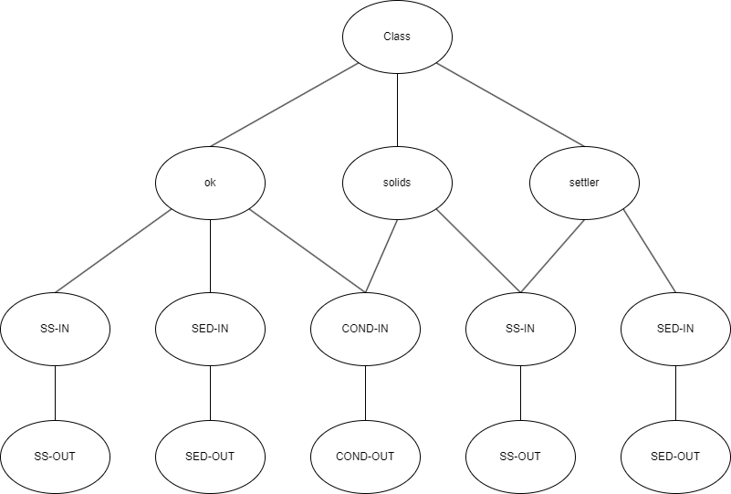

1. What prediction will the naive Bayes model return for the following query? SS-IN = 222, SED-IN = 4.5, COND-IN = 1,518, SS-OUT = 74 SED-OUT = 0.25, COND-OUT = 1,642

   The query has a status of the settler class

# 4 Transforming a Continuous Feature to a Categorical Feature

The table below lists a dataset containing details of policy holders at an insurance company. The descriptive features included in the table describe each policy holders’ ID, occupation, gender, age, the type of insurance policy they hold, and their preferred contact channel. The preferred contact channel is the target feature in this domain.

| ID | Occupation | Gender | Age | Policy Type | Pref Channel |
| --- | --- | --- | --- | --- | --- |
| 1 | lab tech | female | 43 | planC | email |
| 2 | farmhand | female | 57 | planA | phone |
| 3 | biophysicist | male | 21 | planA | email |
| 4 | sheriff | female | 47 | planB | phone |
| 5 | painter | male | 55 | planC | phone |
| 6 | manager | male | 19 | planA | email |
| 7 | geologist | male | 49 | planC | phone |
| 8 | messenger | male | 51 | planB | email |
| 9 | nurse | female | 18 | planC | phone |

Data for a insurance policy model.

1. Using equal-frequency binning transform the Age feature into a categorical feature with three levels: young, middle-aged, mature.

   Young: Age <= 21

   Middle-aged: 22 <= Age <= 49

   Mature: Age >= 50
2. Examine the descriptive features in the dataset and list the features that you would exclude before you would use the dataset to build a predictive model. For each feature you decide to exclude, explain why you have made this decision.

   ID: This feature should be excluded because it is a unique idetifier and does not provide any meaningful information for prediction.

   Occupation: While it might contain useful information, it can introduce too many categorical levels, making it difficult to model efficiently without further preprocessing
3. Calculate the probabilities required by a naive Bayes model to represent this domain.

# 5 Another Naive Bayes Model

Imagine that you have been given a dataset of 1,000 documents that have been classified as being about entertainment or education. There are 700 entertainment documents in the dataset and 300 education documents in the dataset. The tables below give the number of documents from each topic that a selection of words occurred in.

| fun | is | machine | christmas | family | learning |
| --- | --- | --- | --- | --- | --- |
| 415 | 695 | 35 | 0 | 400 | 70 |

Word-document counts for the entertainment dataset.

| fun | is | machine | christmas | family | learning |
| --- | --- | --- | --- | --- | --- |
| 200 | 295 | 120 | 0 | 10 | 105 |

Word-document counts for the education dataset.

1. What target level will a naive Bayes model predict for the following query document: machine learning is fun